# Ecological Communities

# in

# Evolutionary Computation

### By Emily Dolson and Charles Ofria

@emilyldolson dolsonem@msu.edu

## Evolutionary Computation

[figure not shown]

Using evolution as a machine learning algorithm

Image credit: [Alan Zucconi](https://www.alanzucconi.com)

## Evolutionary Computation Works

[figure not shown]

Antenna evolved for NASA

Hornby et al, 2008

## But it requires a diverse population

[figure not shown]

Populations can get stuck on part of the fitness landscape and not explore the rest

Image credit: Bjorn Ostman and Randy Olson

## Diversity maintenance techniques

[figure not shown]

There are a lot of them. Most involve creating ecological interactions.

## Fitness sharing

$$sh(d) = \begin{cases} 1 - (\frac{d}{\sigma_{\text{share}}})^{\alpha} & d < \sigma_{\text{share}}\\ 0 & d \geq \sigma_{\text{share}} \end{cases}$$

Decrease solutions' fitness based on quantity of similar organisms in the population

Goldberg and Richardson, 1987

## Fitness sharing

[figure not shown]

The population partitions the genotype/phenotype space in the same way that species in nature partition resources

Image credit: Charles Darwin

## Eco-EA

Associates sub-components of a problem with limited resources

[figure not shown]

Community is governed by standard resource-competition theory

Goings and Ofria, 2012

## Lexicase selection

Populations are evaluated on N criteria in a random order. Best are kept at each step until 1 remains.

#### Example population

| id | A | B | C |
| --- | --- | --- | --- |
| 1 | 4 | 1 | 2 |
| 2 | 1 | 3 | 5 |
| 3 | 2 | 0 | 5 |

[figure not shown]

Spatially heterogeneous meta-community with unlimited dispersal and intense competitive exclusion.

Spector et al, 2012

## What do these communities look like?

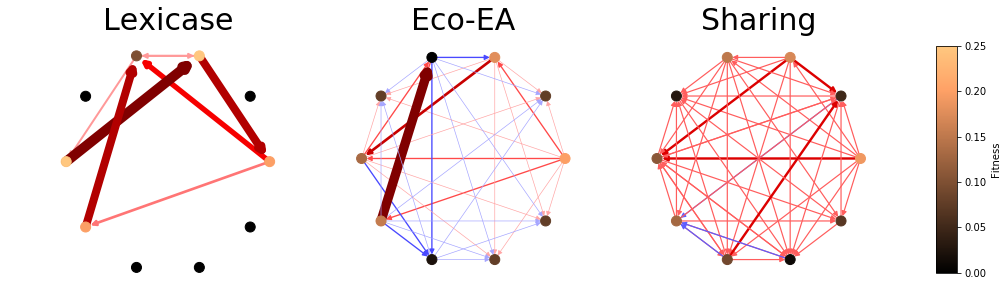

## What are the long term evolutionary effects?

[figure not shown]

## Conclusions

- Importing ecological theory into EC can help solve problems
- EC is a trove of eco-evolutionary dynamics data

## Questions?

[figure not shown]

Image credit: [Context Free Art user jwmatthysn](https://www.contextfreeart.org/gallery2/#design/2691)

@emilyldolson dolsonem@msu.edu